# 2016 IL Financial Contributions to Presidential Campaigns version 2

Sunny Jiang

November 10, 2017

## Data Explore and Analysis

### Univariate

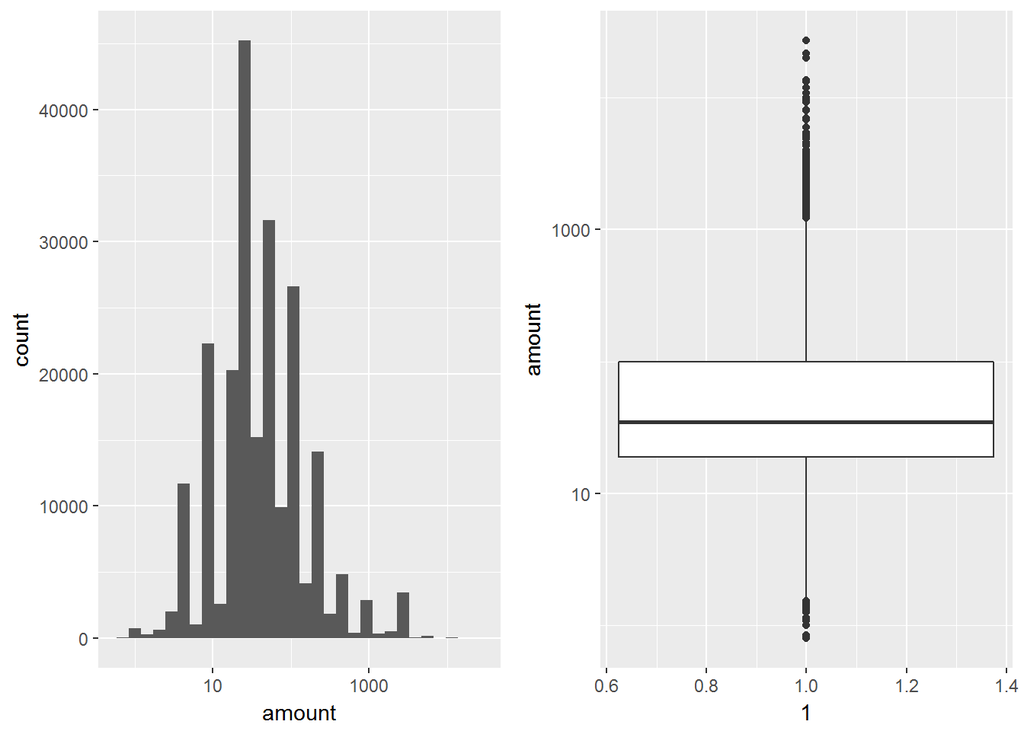

To elimate the noise, we can plot only the ones within 1% to 99% percentile. We can see most contribution amounts are within $0 to $1000 range, after zoom in we can see most amount are actully less than $250.

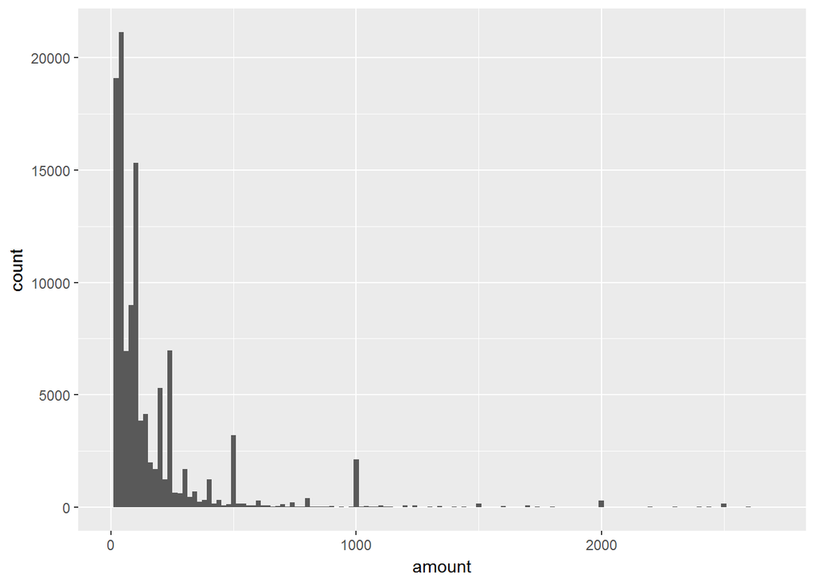

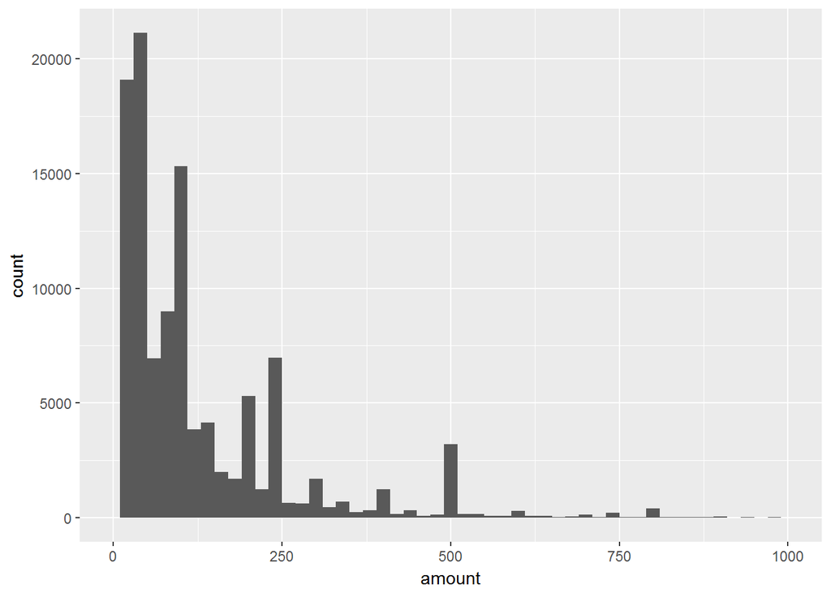

From the the first boxplot we can see, this dataset has a few data points that incorrectly mapped to Illinois. And when plot the count by county for IL. Cook county contirbutes most of the contributions.

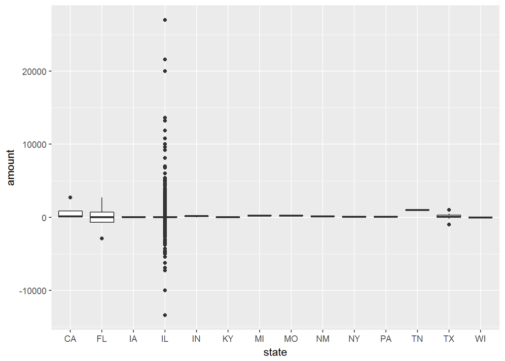

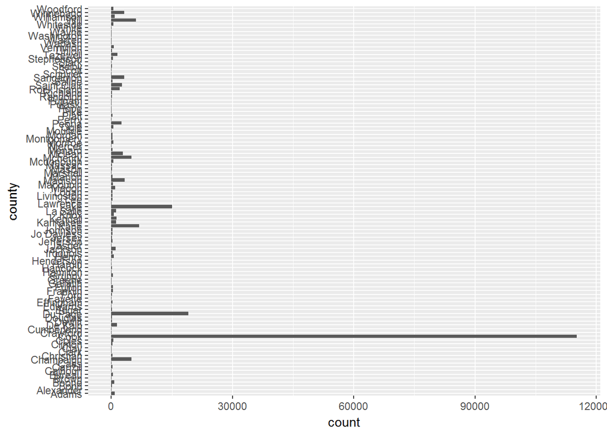

From two bar charts we can see most people only contributed less than 3 times. And only supported 1 candidate.

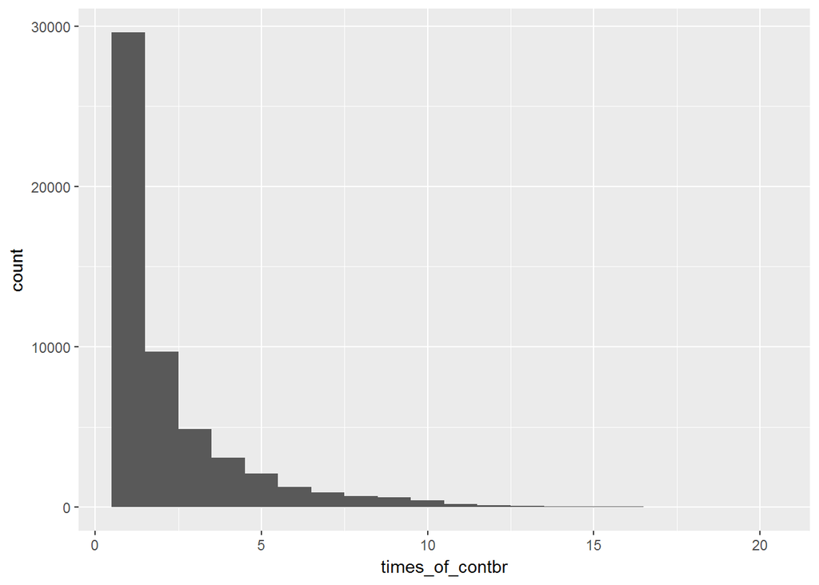

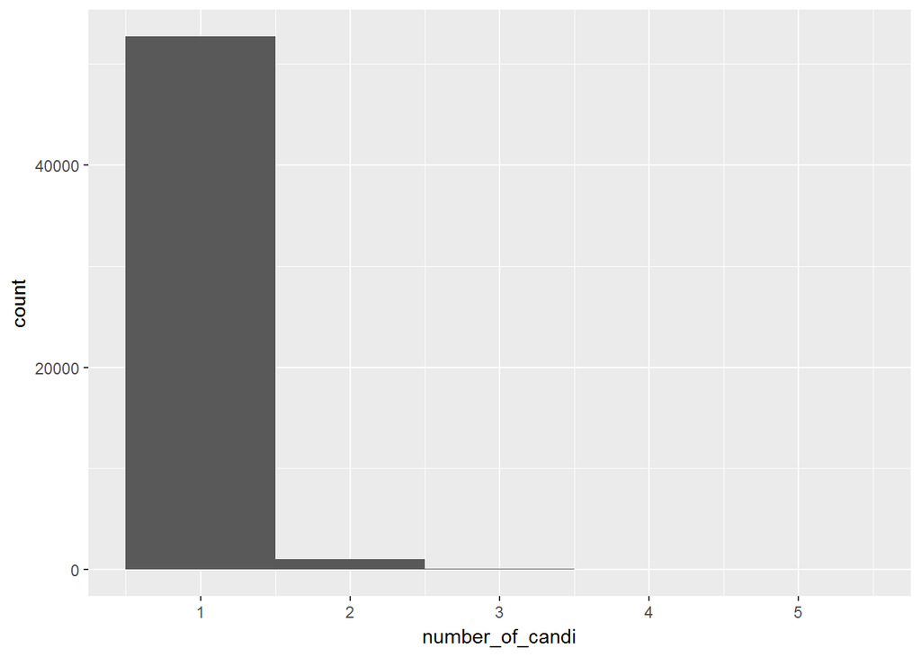

### Bivariate

Take a closer look through the heatmap: 55% of people only contributed once to one candidate and covers 41% of total contribution amount in IL.

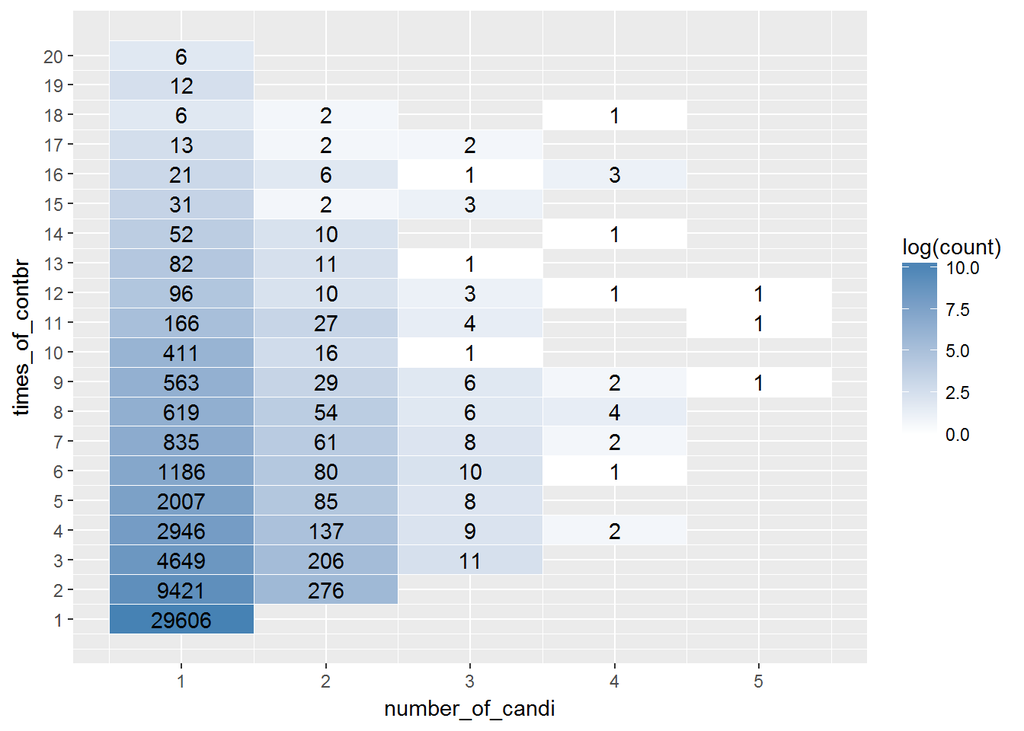

Contribution amount distribution for each candidate. Cruz has the highest contribution amount.

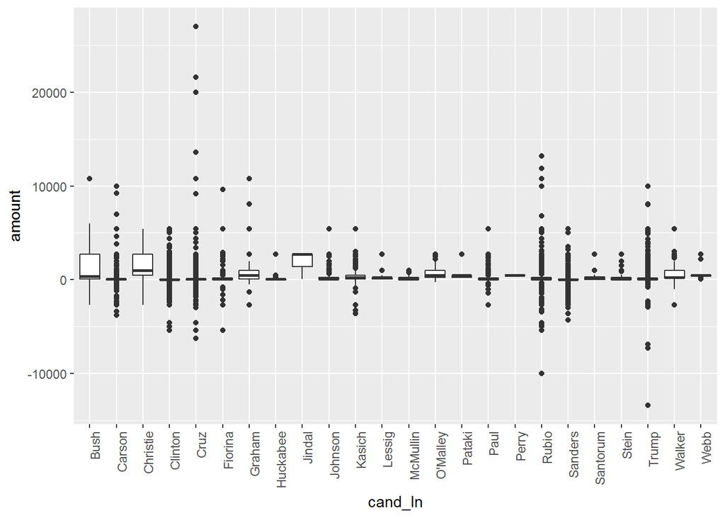

From these two bar charts, we can see **Clinton**, **Sanders**, **Cruz** and **Trump** are the top 4 condidates by both contribution count and amount

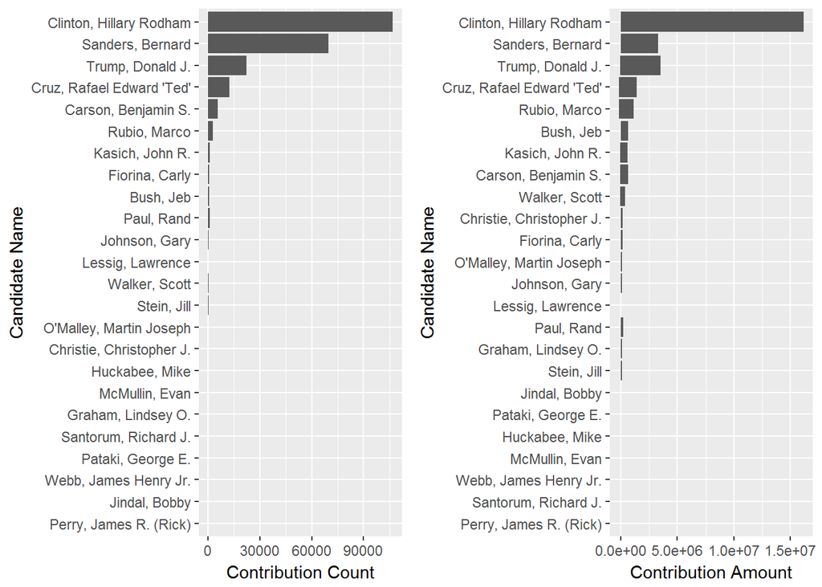

Contribution amount distribution for each county, this chart is too busy to see anything. So I tried treemap.

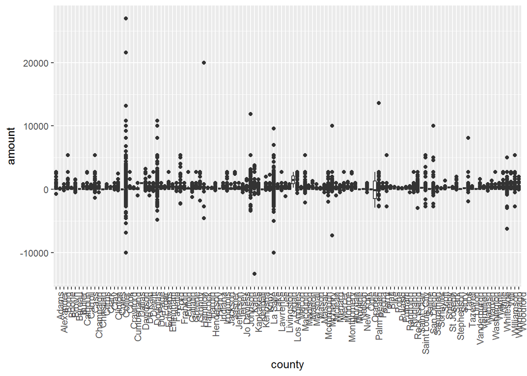

From these two treemap charts, we can see Cook County has the highest contribution amount. When I broke down to City and zipcode level for Cook County, Chicago is the top 1. Size corresponds to Amount and Color corresponds to Count.

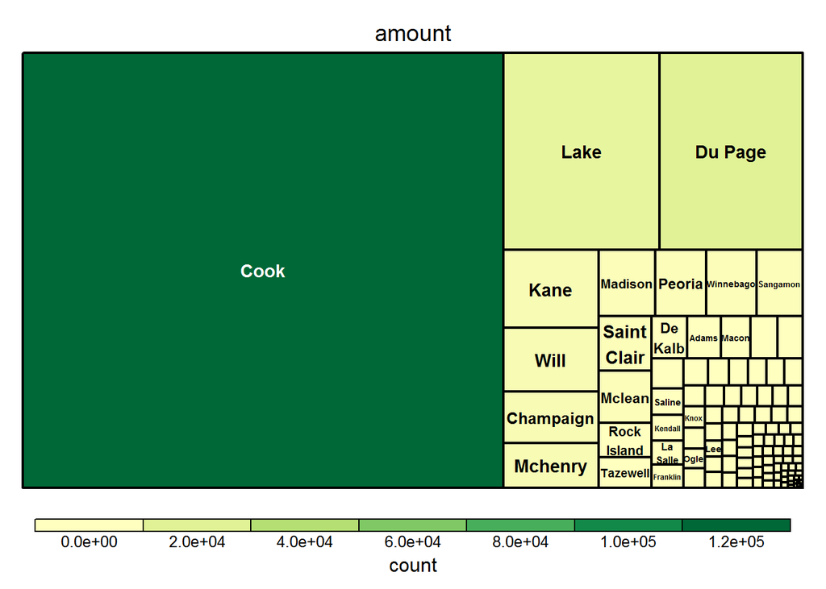

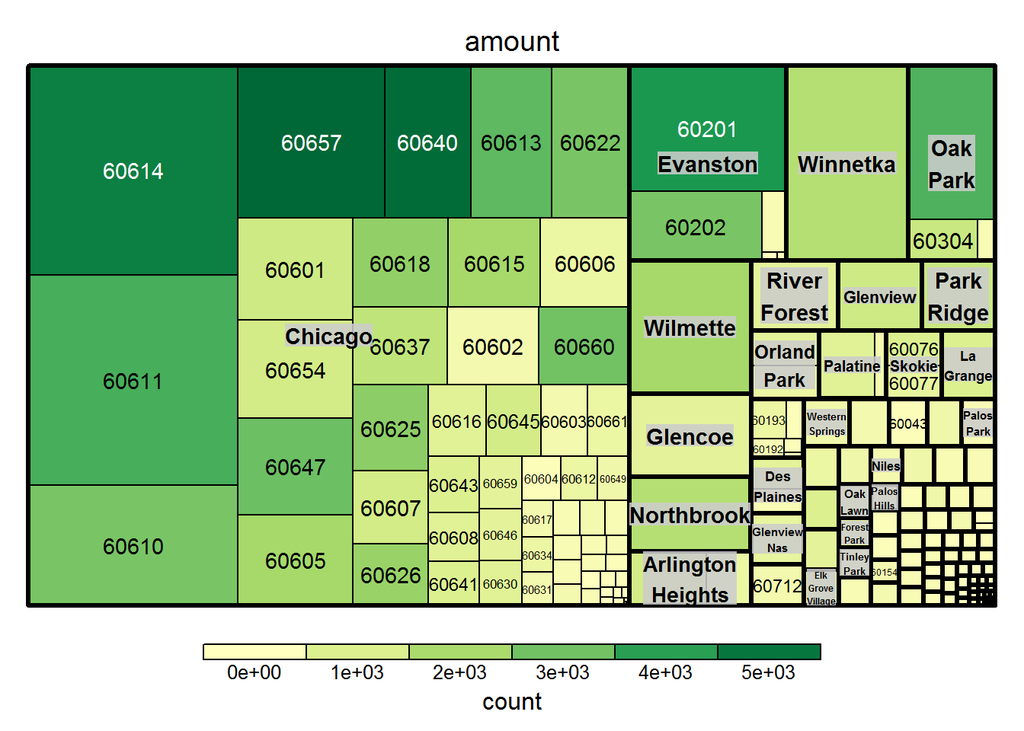

### Multivariate

For our top 4 candidates:

**Bernie Sanders** announced that he plan to seek the Democratic Party’s nomination for President of the United States on May 26, 2015. On June 14, 2016, following the final primary election, Clinton became the presumptive Democratic nominee. As we can see from the time series chart, contribution made for Sanders were between May 2015 to July 2016, peaked on March 2016. Matches his campaign timeline.

**Ted Cruz** announced his presidential campaign on March 23, 2015. And suspended his campaign late April 2016. The contribution amount to him were higher than to Trump until he suspended his campaign.

**Donald Trump** formally launched his campaign on June 16, 2015. On May 3, 2016 Trump became the presumptive nominee of the Republican Party, and elected as president on November 8, 2016. From the chart we can see, contribution to him was really low at the beginning and started to take off on May 2016 after he became the presumptive nominee of Republican Party.

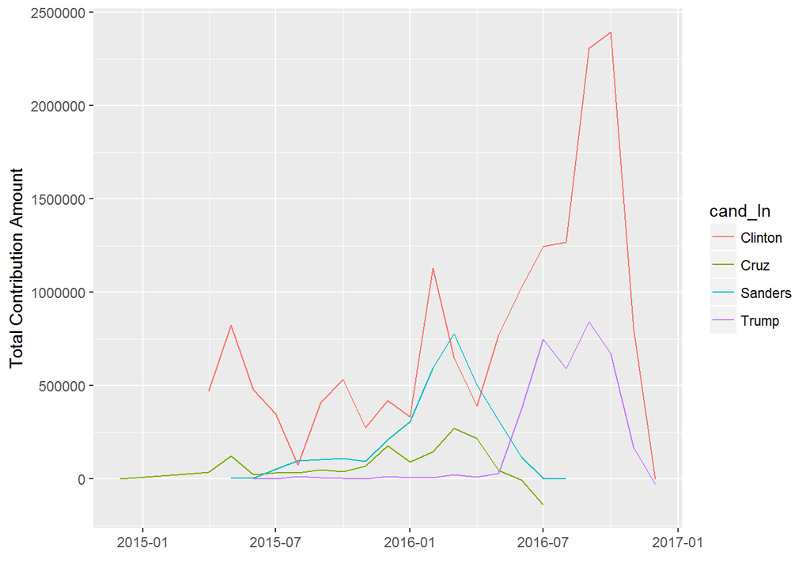

Then study the distirbution for top 4 candidates with boxplot. Sanders has the lowest median contribution amount around $60. We can see some darker lines at $10, $30 and $100 which means a lot of contribution at those amounts. While Clinton has the hightest median contribution amount around $100, and have a lot of contributed at $50, $100, $500 and $2500. The highest contribution amount is $27000, and contributed to Cruz.

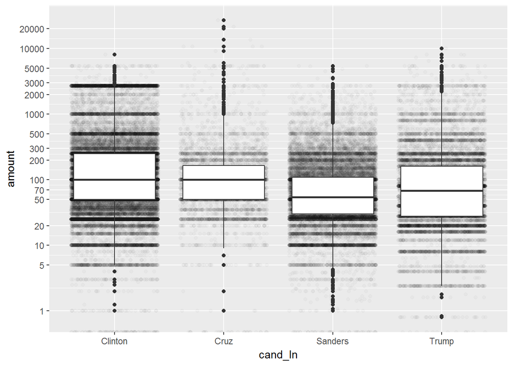

The first treemap shows that for Cook County, most of the contribtuion went to Clinton, then Sanders. From the second one, we can see Clinton had most of all the contribtutions. Trump and Sanders had similar amount.

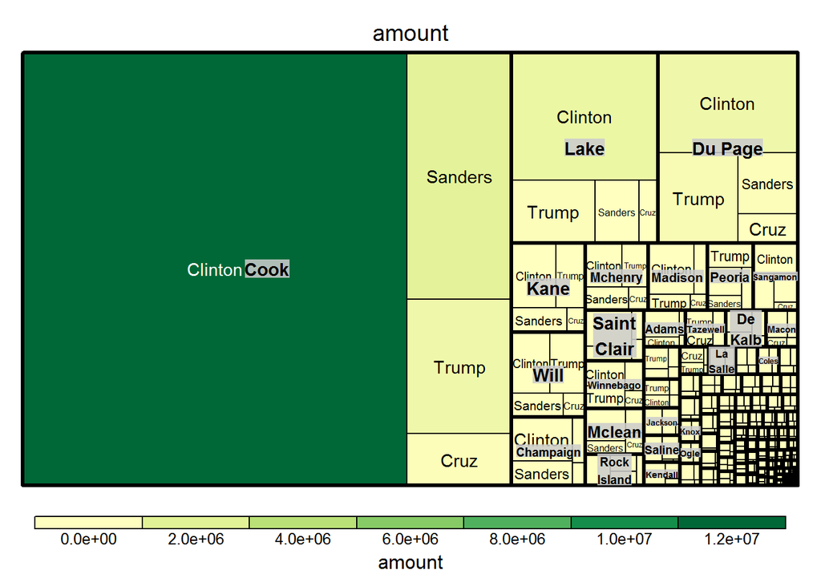

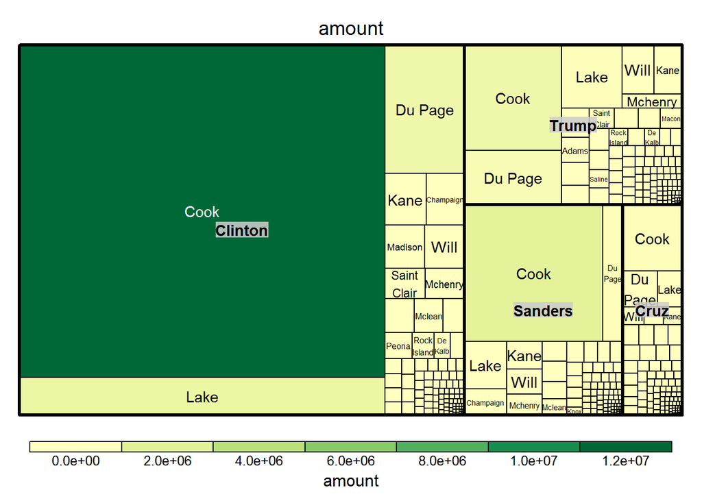

I picked the top 10 counties with the highest contribution amount. And used boxplot and barchart to see the distiribtution for top 4 candidates. Contritubiton to Clinton from Cook county really dominated it. But in some counties like Peoria, the contirbution to Trump was higher.

```
## # A tibble: 10 × 3
##       county     amount count
##       <fctr>      <dbl> <int>
## 1       Cook 17164865.5  1293
## 2       Lake  2530415.7   254
## 3    Du Page  2321158.6   340
## 4       Kane   612205.7   160
## 5       Will   499676.7   155
## 6  Champaign   401656.1   125
## 7    Mchenry   350258.3   120
## 8    Madison   310797.9   113
## 9     Peoria   276963.3   122
## 10 Winnebago   274612.0   124
```

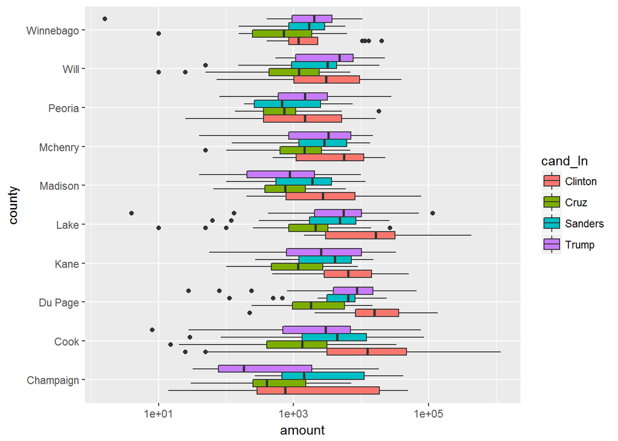

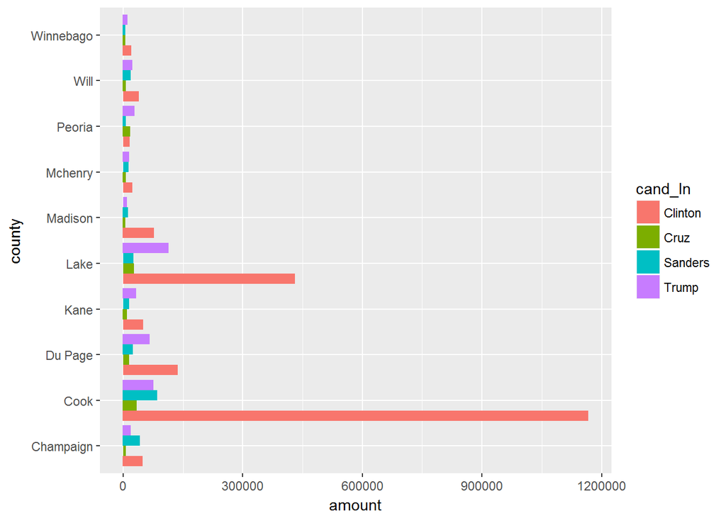

Plot the contribution amount by zipcode. Can’t really find a lot information except we can identify the big cities like Chicago, Peoria, Springfield…

[output not shown]

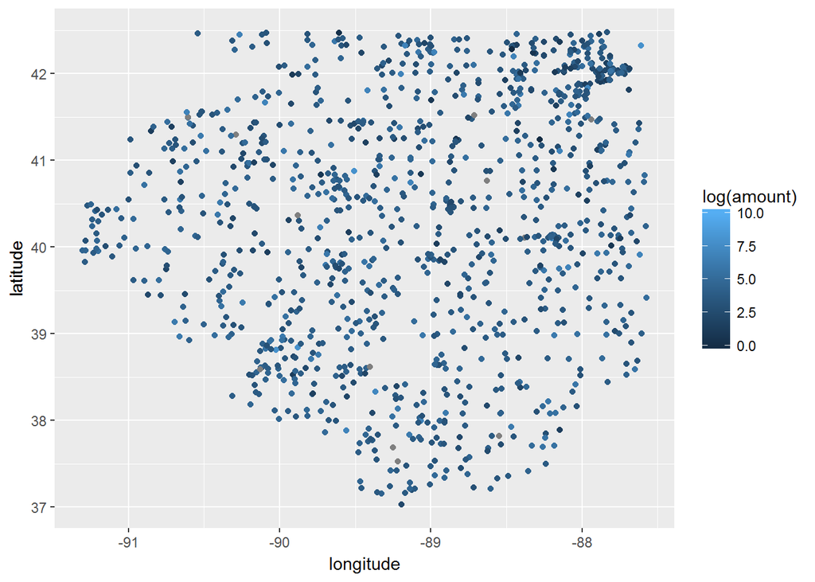

## Final Plots and Summary

### Plot One

**Bernie Sanders** announced that he plan to seek the Democratic Party’s nomination for President of the United States on May 26, 2015. On June 14, 2016, following the final primary election, Clinton became the presumptive Democratic nominee. As we can see from the time series chart, contribution made for Sanders were between May 2015 to July 2016, peaked on March 2016. Matches his campaign timeline.

**Ted Cruz** announced his presidential campaign on March 23, 2015. And suspended his campaign late April 2016. The contribution amount to him were higher than to Trump until he suspended his campaign.

**Donald Trump** formally launched his campaign on June 16, 2015. On May 3, 2016 Trump became the presumptive nominee of the Republican Party, and elected as president on November 8, 2016. From the chart we can see, contribution to him was really low at the beginning and started to take off on May 2016 after he became the presumptive nominee of Republican Party.

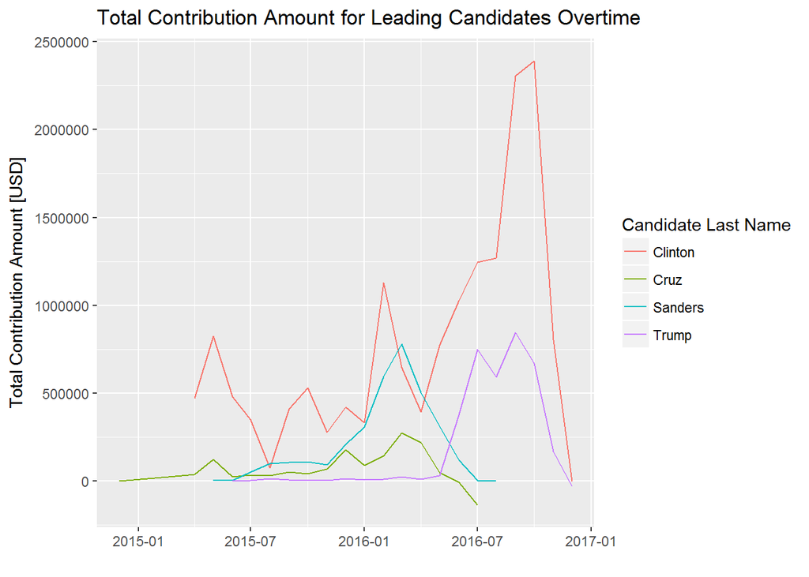

### Plot Two

Then study the distirbution for top 4 candidates with boxplot. Sanders has the lowest median contribution amount around $60. We can see some darker lines at $10, $30 and $100 which means a lot of contribution at those amounts. While Clinton has the hightest median contribution amount around $100, and have a lot of contributed at $50, $100, $500 and $2500. The highest contribution amount is $27000, and contributed to Cruz.

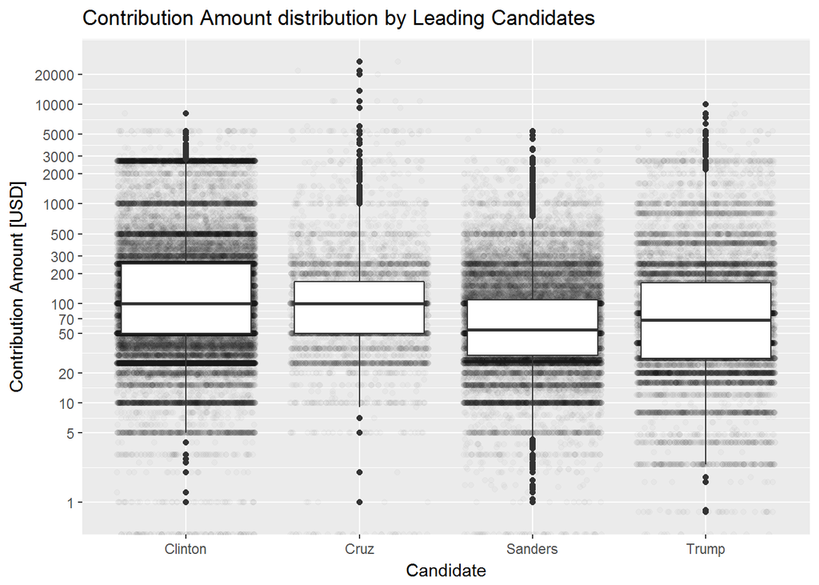

### Plot Three

55% of people only contributed once to one candidate and covers 41% of total contribution amount in IL. This tells us for most people making contirbution was a one time only thing through a campaign event. Less amount of people made contirbution repetitively or supported multiple candidates over time

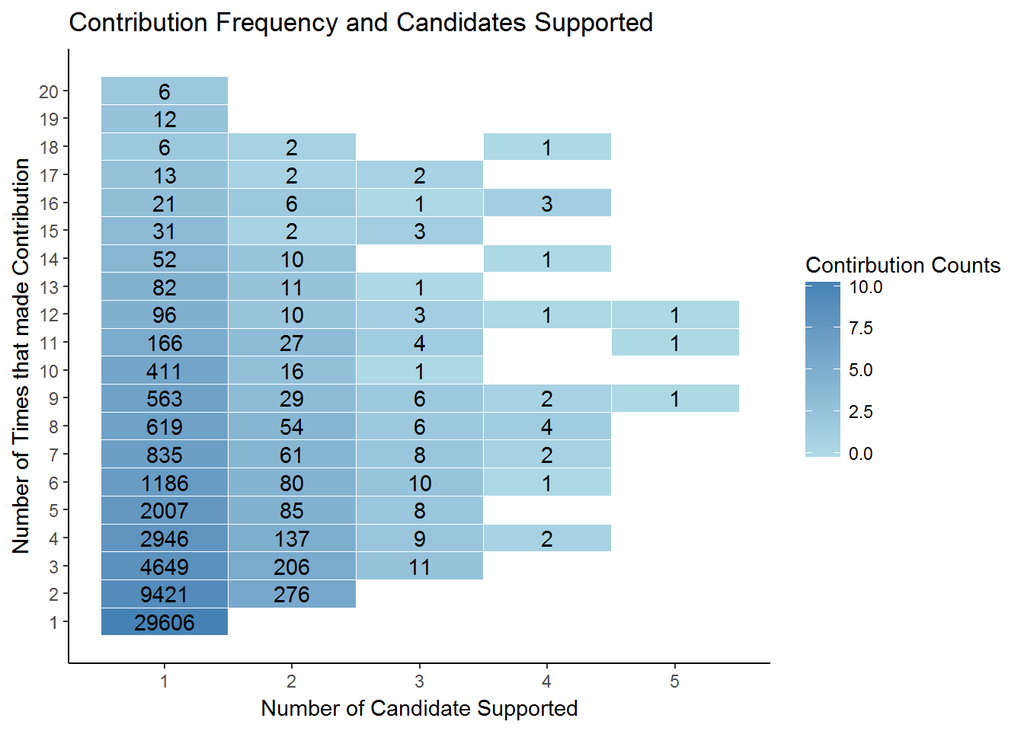

## Reflection

- Since I’m living in Peoira Illinois, I choosed Illinois data for this study.
- I know Clint won the Illinois electoral votes, so I assumed she got most of the contribution. Which turns out true.
- When I tried to map the location by zip code, I noticed that there are a few records that actually outside Illinois. For future exploration I should eliminate those records up front.
- Another idea is group the zip code by county and compare with the final results. So we can see in detail whether the contribution amount affects the final results.